# STAT340 Discussion 3: Monte Carlo

## 2. Flipping coins

Suppose you flip a fair coin $N$ times. How many heads in a row should you expect to see? For example, suppose that I flip a coin 20 times, and I get 5 heads in a row at some point in the sequence. Is this a “surprising” outcome?

1. Write code to simulate randomly flipping a fair coin ($p=0.5$) a total of $N=10$ times (hint: use either the `rbernoulli` function from the `purrr` package or `rbinom` with `n=10` and `size=1`) and record how many heads (defined as a value of $1$; tails is $0$) in a row you observe. Determining the length of the longest run has been implemented in the function `longest_head_run` below.

```r
longest_head_run <- function(trials) {
  rle_encoded <- rle(trials)
  head_sequence_indicators <- rle_encoded$values == 1

  if (!any(head_sequence_indicators)) {
    return(0L)
  }

  lengths_head_sequences <- rle_encoded$lengths[head_sequence_indicators]

  max(lengths_head_sequences)
}
rbinom(10, 1, 0.5)
```

```
##  [1] 1 1 0 1 0 1 0 0 1 1
```

```r
longest_head_run(rbinom(10, 1, 0.5))
```

```
## [1] 4
```

2. Repeat the above experiment $M$ times. Set $M$ to be at least $1000$, but don’t make it extremely large, because we are going to repeat the previous step for other values of the number of flips $N$. What is the mean length of the largest run of heads in $N=10$ flips?
   - **Note:** $N$ here is the *size of each experiment*. That is, each experiment consists of $N$ flips. On the other hand, $M$ is *how many experiments* are performed (i.e., the number of times we repeat the experiment). It is common when using Monte Carlo methods to have two types of parameters: one type for the properties of each experiment (e.g., $N$, in this case), and one type that determines how many experiments are done (here, $M$). Increasing $N$ (number of flips in each experiment) will change the experiment by increasing the mean-run-length, whereas increasing $M$ (the number of experiments) will increase the precision of the estimate of the mean run length for a particular number of flips $N$.

```r
NMC <- 1000; # 1000 seems like "a lot".
results <- rep( 0, NMC ); # We're going to record outcomes here.
for( i in 1:NMC) {
  # Generate a draw from the normal, and then...
  #X <- rnorm( 1, mean=1, sd=sqrt(3) );
  # ...record whether or not our event of interest happened.
  results[i] <- longest_head_run(rbinom(10, 1, 0.5));
}
# Now, compute what fraction of our trials were "successes" (i.e., E happened)
sum( results )/NMC
```

```
## [1] 2.857
```

3. Now, repeat the above (you may use the same $M$) for *at least 3* other values of $N$ (again, feel free to do more if you wish!). Display your results in a table.
   - **Note:** this step should be easy if you’ve written your code with good style. I recommend writing a function that does all the above for any given $N$ and $M$ and, optionally, $p$. For example, something like `find_mean_run <- function(N, M, p = 0.5) {......}`. Then, for different values of $N$ and $M$ you can simply change the arguments given to the function, e.g. `find_mean_run(10, 1000)` or `find_mean_run(20, 1000)`, etc., then put them in a data frame.
   - **Note:** the above function syntax sets `N` and `M` as arguments to the function without default values, but sets `0.5` as the default value of the argument `p`. For a different example, [see this](https://www.javatpoint.com/r-function-default-arguments).

```r
NMC <- 1000; # 1000 seems like "a lot".
results <- rep( 0, NMC ); # We're going to record outcomes here.
for( i in 1:NMC) {
  # Generate a draw from the normal, and then...
  #X <- rnorm( 1, mean=1, sd=sqrt(3) );
  # ...record whether or not our event of interest happened.
  results[i] <- longest_head_run(rbinom(20, 1, 0.5));
}
# Now, compute what fraction of our trials were "successes" (i.e., E happened)
sum( results )/NMC
```

[output not shown]

```r
NMC <- 1000; # 1000 seems like "a lot".
results <- rep( 0, NMC ); # We're going to record outcomes here.
for( i in 1:NMC) {
  # Generate a draw from the normal, and then...
  #X <- rnorm( 1, mean=1, sd=sqrt(3) );
  # ...record whether or not our event of interest happened.
  results[i] <- longest_head_run(rbinom(50, 1, 0.5));
}
# Now, compute what fraction of our trials were "successes" (i.e., E happened)
sum( results )/NMC
```

```
## [1] 5.066
```

```r
NMC <- 1000; # 1000 seems like "a lot".
results <- rep( 0, NMC ); # We're going to record outcomes here.
for( i in 1:NMC) {
  # Generate a draw from the normal, and then...
  #X <- rnorm( 1, mean=1, sd=sqrt(3) );
  # ...record whether or not our event of interest happened.
  results[i] <- longest_head_run(rbinom(1000, 1, 0.5));
}
# Now, compute what fraction of our trials were "successes" (i.e., E happened)
sum( results )/NMC
```

```
## [1] 9.337
```

4. Validate your results against other people’s results (for example, [this post](https://math.stackexchange.com/a/1409539)). Are your results consistent with others?
5. **Bonus:** run a few more values of $N$ and plot the results, showing the mean run length as a function of the number of flips $N$. (bonus²: what happens if you increase $M$?)

```r
vector1 =  rep( 0, 1000 );
for(j in 1:1000){
  NMC <- 1000; # 1000 seems like "a lot".
  results <- rep( 0, NMC ); # We're going to record outcomes here.
  for( i in 1:NMC) {
    # Generate a draw from the normal, and then...
    #X <- rnorm( 1, mean=1, sd=sqrt(3) );
    # ...record whether or not our event of interest happened.
    results[i] <- longest_head_run(rbinom(20, 1, 0.5));
  }
  # Now, compute what fraction of our trials were "successes" (i.e., E happened)
  vector1[j] = sum( results )/NMC

}
vector1
```

[output not shown]

[output cut: 69 more lines]

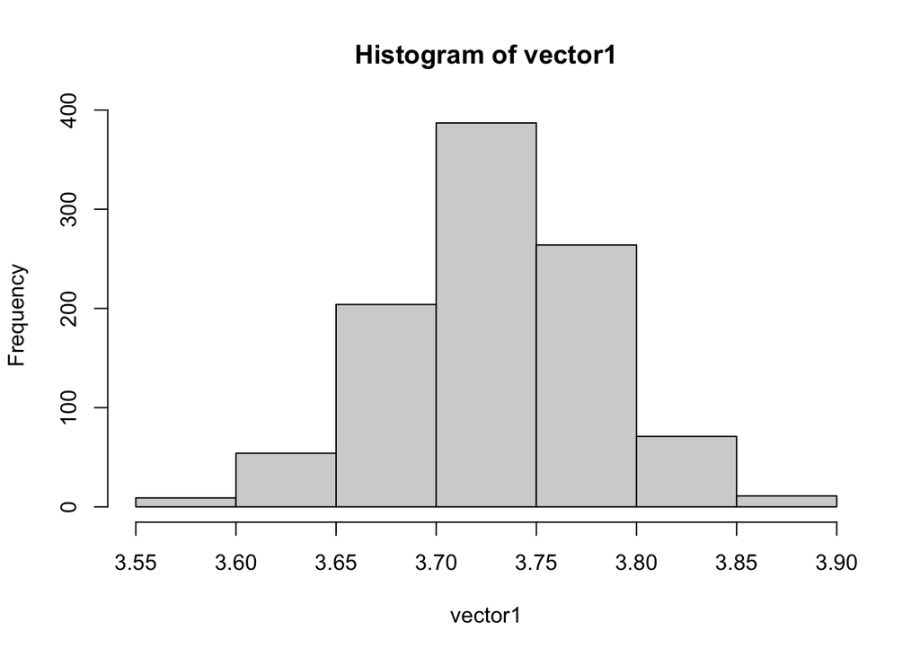

```r
hist(vector1)
```

6. **Super bonus:** Like [the post referenced above](https://math.stackexchange.com/questions/1409372/what-is-the-expected-length-of-the-largest-run-of-heads-if-we-make-1-000-flips/1409539#1409539), can you fit a smooth curve through the points?

```r
# given output of rbernoulli or rbinom (a vector of 0's and 1's)
# compute the length of the longest continuous run of 1's
longest_head_run <- function(trials) {
  rle_encoded <- rle(trials)
  head_sequence_indicators <- rle_encoded$values == 1

  if (!any(head_sequence_indicators)) {
    return(0L)
  }

  lengths_head_sequences <- rle_encoded$lengths[head_sequence_indicators]

  max(lengths_head_sequences)
}

# demo of using longest_head_run
longest_head_run(c(0, 0, 0, 0, 0, 0, 0, 0, 0, 0, 0, 0)) # returns 0
```

```
## [1] 0
```

```r
longest_head_run(c(1, 0, 1, 1, 0, 1, 1, 1, 0, 0, 0, 0)) # returns 3
```

```
## [1] 3
```